# W3cubDocs

## Persist the data

Let’s go through the same workflow once more to add a Redis database for storing app data.

1. Save this new `docker-compose.yml` file, which finally adds a Redis service. Be sure to replace `username/repo:tag` with your image details.

   ```
   version: "3"
   services:
     web:
       # replace username/repo:tag with your name and image details
       image: username/repo:tag
       deploy:
         replicas: 5
         restart_policy:
           condition: on-failure
         resources:
           limits:
             cpus: "0.1"
             memory: 50M
       ports:
         - "80:80"
       networks:
         - webnet
     visualizer:
       image: dockersamples/visualizer:stable
       ports:
         - "8080:8080"
       volumes:
         - "/var/run/docker.sock:/var/run/docker.sock"
       deploy:
         placement:
           constraints: [node.role == manager]
       networks:
         - webnet
     redis:
       image: redis
       ports:
         - "6379:6379"
       volumes:
         - "/home/docker/data:/data"
       deploy:
         placement:
           constraints: [node.role == manager]
       command: redis-server --appendonly yes
       networks:
         - webnet
   networks:
     webnet:
   ```

   Redis has an official image in the Docker library and has been granted the short `image` name of just `redis`, so no `username/repo` notation here. The Redis port, 6379, has been pre-configured by Redis to be exposed from the container to the host, and here in our Compose file we expose it from the host to the world, so you can actually enter the IP for any of your nodes into Redis Desktop Manager and manage this Redis instance, if you so choose.

   Most importantly, there are a couple of things in the `redis` specification that make data persist between deployments of this stack:
   - `redis` always runs on the manager, so it’s always using the same filesystem.
   - `redis` accesses an arbitrary directory in the host’s file system as `/data` inside the container, which is where Redis stores data.

   Together, this is creating a “source of truth” in your host’s physical filesystem for the Redis data. Without this, Redis would store its data in `/data` inside the container’s filesystem, which would get wiped out if that container were ever redeployed.

   This source of truth has two components:
   - The placement constraint you put on the Redis service, ensuring that it always uses the same host.
   - The volume you created that lets the container access `./data` (on the host) as `/data` (inside the Redis container). While containers come and go, the files stored on `./data` on the specified host persists, enabling continuity.

   You are ready to deploy your new Redis-using stack.
2. Create a `./data` directory on the manager:

   ```
   docker-machine ssh myvm1 "mkdir ./data"
   ```

3. Make sure your shell is configured to talk to `myvm1` (full examples are here).
   - Run `docker-machine ls` to list machines and make sure you are connected to `myvm1`, as indicated by an asterisk next to it.
   - If needed, re-run `docker-machine env myvm1`, then run the given command to configure the shell.

     On **Mac or Linux** the command is:

     ```
     eval $(docker-machine env myvm1)
     ```

     On **Windows** the command is:

     ```
     & "C:\Program Files\Docker\Docker\Resources\bin\docker-machine.exe" env myvm1 | Invoke-Expression
     ```

4. Run `docker stack deploy` one more time.

   ```
   $ docker stack deploy -c docker-compose.yml getstartedlab
   ```

5. Run `docker service ls` to verify that the three services are running as expected.

   ```
   $ docker service ls
   ID                  NAME                       MODE                REPLICAS            IMAGE                             PORTS
   x7uij6xb4foj        getstartedlab_redis        replicated          1/1                 redis:latest                      *:6379->6379/tcp
   n5rvhm52ykq7        getstartedlab_visualizer   replicated          1/1                 dockersamples/visualizer:stable   *:8080->8080/tcp
   mifd433bti1d        getstartedlab_web          replicated          5/5                 gordon/getstarted:latest    *:80->80/tcp
   ```

6. Check the web page at one of your nodes, such as `http://192.168.99.101`, and take a look at the results of the visitor counter, which is now live and storing information on Redis.

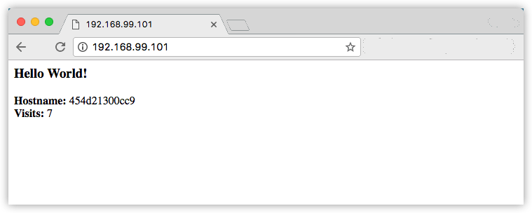

   Also, check the visualizer at port 8080 on either node’s IP address, and notice the `redis` service running along with the `web` and `visualizer` services.

[figure not shown]

On to Part 6 >>

## Recap (optional)

Here’s [a terminal recording of what was covered on this page](https://asciinema.org/a/113840):

You learned that stacks are inter-related services all running in concert, and that -- surprise! -- you’ve been using stacks since part three of this tutorial. You learned that to add more services to your stack, you insert them in your Compose file. Finally, you learned that by using a combination of placement constraints and volumes you can create a permanent home for persisting data, so that your app’s data survives when the container is torn down and redeployed.

stack, data, persist, dependencies, redis, storage, volume, port